# Caso Práctico 07: BMW vs Volkswagen

Daniel Corral Ruiz

2020-12-13

## Objetivos informe

Utilizando datos diarios de los dos series desde el año 2014, debemos analizar la relación entre BMW y Volkswagen utilizando el modelo de Causal Impact, para estimar el efecto del diesel gate.

## Carga de datos

Comenzamos cargando el dataset mediante la librería “quantmod”. Esta librería nos permite obtener la información financiera de empresas durante un periodo de tiempo determinado. Descargamos los datos de BMW y Volkswagen entre 2014-01-01 y 2020-12-12.

```
## [1] "BMW.DE"
```

```
## [1] "VOW.DE"
```

## Diesel gate

En septiembre de 2015 salió a la luz que Volkswagen había instalado ilegalmente un software para alterar los resultados de los controles técnicos de emisiones contaminantes en 11 millones de automóviles con motor diésel, vendidos entre 2009 y 2015. Como resultado de este fraude, sus motores habían superado con creces los estándares de la Agencia de Protección Ambiental de Estados Unidos (EPA). Los vehículos implicados emiten en condiciones reales hasta 40 veces el límite legal de óxidos de nitrógeno.

A continuación mostramos los gráficos del efecto de impacto para Volkswagen. En el primer grafico encontramos la predicción en azul en el caso de que no hubiera habido intervención, mientras que en el segundo grafico encontramos la ganancia, es decir, la diferencia entre la predicción y lo real.

```
## Posterior inference {CausalImpact}
##
##                          Average        Cumulative
## Actual                   136            182749
## Prediction (s.d.)        155 (16)       207564 (21676)
## 95% CI                   [124, 188]     [166267, 252378]
##
## Absolute effect (s.d.)   -19 (16)       -24815 (21676)
## 95% CI                   [-52, 12]      [-69629, 16481]
##
## Relative effect (s.d.)   -12% (10%)     -12% (10%)
## 95% CI                   [-34%, 7.9%]   [-34%, 7.9%]
##
## Posterior tail-area probability p:   0.1247
## Posterior prob. of a causal effect:  88%
##
## For more details, type: summary(impact, "report")
```

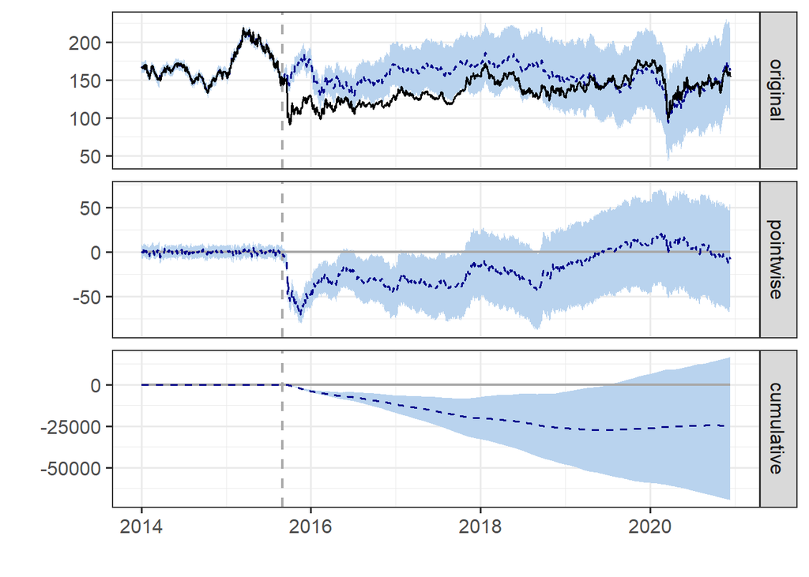

[output not shown]

A continuación mostramos los gráficos del efecto de impacto para BMW. En el primer grafico encontramos la predicción en azul en el caso de que no hubiera habido intervención, mientras que en el segundo grafico encontramos la ganancia, es decir, la diferencia entre la predicción y lo real.

```
## Posterior inference {CausalImpact}
##
##                          Average       Cumulative
## Actual                   67            89298
## Prediction (s.d.)        60 (6.6)      80129 (8817.2)
## 95% CI                   [48, 73]      [63615, 98365]
##
## Absolute effect (s.d.)   6.8 (6.6)     9169.1 (8817.2)
## 95% CI                   [-6.8, 19]    [-9066.5, 25683]
##
## Relative effect (s.d.)   11% (11%)     11% (11%)
## 95% CI                   [-11%, 32%]   [-11%, 32%]
##
## Posterior tail-area probability p:   0.15085
## Posterior prob. of a causal effect:  85%
##
## For more details, type: summary(impact, "report")
```

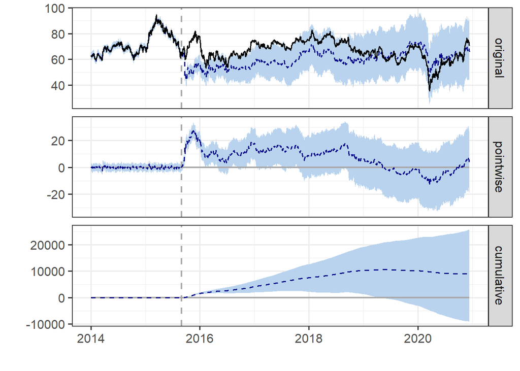

[output not shown]